# Laboratorio 1

Joshua Cervantes

18 May 2022

# Ejercicio 1

Considere un seguro de vida temporal a 10 años que paga un beneficio de 1.000, sobre una población $l_{50}$ a la edad de 50 años. Se utiliza la tabla ilustrativa del Bowers con una tasa de interés del 6%.

1. Se solicita calcular la prima de riesgos

```r
# Se estiman las probabilidades de sobrevivencia al a\~no siguiente
px <- tabla$lx[-1] / tabla$lx[-length(tabla$lx)]
px[length(px) + 1] <- 0
# Se genera una tabla de sobrevivencia a partir de las probabilidades calculadas
life_table <- probs2lifetable(px, type = "px")
benefit <- 1000

# Se calcula la prima usando la formula empleando del principio de equivalencia
nAx <- Axn(life_table, x = 50, n = 10, i = 0.06)
nax <- axn(life_table, x = 50, n = 10, i = 0.06)

# Prima de riesgo
premium <- benefit * nAx / nax
premium
```

```
## [1] 7,9872
```

2. Se debe conformar una tabla con los flujos y los valores de reserva de la reserva en cada año.

```r
# Se genera un tabla para los flujos
# Se calculan los valoresq que pueden ser estiamdos de forma vectorial
# Sobreviviente de 50 años a 60 años
lx <- tabla$lx[51:61]
year <- 1:10
E_survival <- lx[-length(lx)]
E_premium <- E_survival * premium
E_reclaims <- -diff(lx) * 1000
E_i <- E_premium[1] * 0.06
E_funds_b <- E_premium[1]
E_funds_e <- E_premium[1] + E_i[1] - E_reclaims[1]
E_survival_e <- lx[-1]
for (i in 2:10) {
  E_funds_b[i] <- E_funds_e[i - 1] + E_premium[i]
  E_i[i] <- E_funds_b[i] * 0.06
  E_funds_e[i] <- E_funds_b[i] + E_i[i] - E_reclaims[i]
}
reserve <- E_funds_e / E_survival_e
flows <- data.frame(year, E_survival, E_premium, E_funds_b, E_i, E_reclaims, E_funds_e, reserve)
kable(flows,
  col.names = c(
    "Año", "Sobrevientes al inicio", "Primas esperadas", "Fondos esperados al inicio",
    "Intereses esperados", "Reclamos esprados", "Fondos esperados al final", "Reserva"
  ),
  caption = "Flujos", format.args = list(decimal.mark = ",", big.mark = ".")
) %>%
  kable_styling(full_width = F) %>%
  kable_material() %>%
  row_spec(0, bold = T, color = "white", background = "#159957") %>%
  scroll_box(height = "500px", width = "100%")
```

Flujos

| Año | Sobrevientes al inicio | Primas esperadas | Fondos esperados al inicio | Intereses esperados | Reclamos esprados | Fondos esperados al final | Reserva |
| --- | --- | --- | --- | --- | --- | --- | --- |
| 1 | 89.509 | 714.929 | 714.929 | 42.896 | 529.890 | 227.935 | 2,5617 |
| 2 | 88.979 | 710.697 | 938.632 | 56.318 | 571.430 | 423.520 | 4,7905 |
| 3 | 88.408 | 706.133 | 1.129.653 | 67.779 | 616.420 | 581.012 | 6,6181 |
| 4 | 87.791 | 701.209 | 1.282.221 | 76.933 | 665.060 | 694.095 | 7,9665 |
| 5 | 87.126 | 695.897 | 1.389.992 | 83.400 | 717.600 | 755.792 | 8,7467 |
| 6 | 86.409 | 690.166 | 1.445.957 | 86.757 | 774.270 | 758.445 | 8,8568 |
| 7 | 85.634 | 683.981 | 1.442.426 | 86.546 | 835.260 | 693.712 | 8,1806 |
| 8 | 84.799 | 677.310 | 1.371.022 | 82.261 | 900.820 | 552.463 | 6,5849 |
| 9 | 83.898 | 670.115 | 1.222.578 | 73.355 | 971.140 | 324.793 | 3,9166 |
| 10 | 82.927 | 662.358 | 987.151 | 59.229 | 1.046.380 | 0 | 0,0000 |

# Ejercicio 2

Un asegurado adquiere un seguro vitalicio a la edad de 50 años. La suma asegurada es de 10.000 y paga al final de año de muerte. Para este ejercicio se considera la tabla del Bowers que se encuentra en la plataforma de virtual y una tasa de interés del 5%.

```r
# Para este ejercicio podemos utilizar mucho de lo que
# se implemento anteriormente respecto a la tabla de sobrevivencia
# Se calcula la prima usando la formula empleando del principio de equivalencia
nAx_2 <- Axn(life_table, x = 50, i = 0.05)
nax_2 <- axn(life_table, x = 50, i = 0.05, payment = "advance")

# Tasas
net_rate <- nAx_2 / nax_2
gross_rate <- net_rate / 0.875
# Primas
gross_premium <- 10000 * net_rate / 0.875
net_premium <- 10000 * net_rate
# Print
# print(paste("La tasa neta es", net_rate, sep = " "))
# print(paste("La tasa bruta sería", gross_rate, sep = " "))
# print(paste("La prima bruta sería", gross_premium, sep = " "))


## El monto de la reserva bajo el concepto de prima bruta sería
V_5 <- 10000 * Axn(life_table, x = 55, i = 0.05) - 0.875 * gross_premium * axn(life_table, x = 55, i = 0.05)
# print(paste("La reserva es", V_5, sep = " "))
```

La la tasa neta es 0,0207, la tasa bruta es 0,02365, la prima bruta es 236,54546 y la reserva en 5 años después de la emisión de la póliza es 835,21913.

2. En un segundo escenario, se calcula la prima neta considerando un 4% de interés, aunque la Compañía espera generar un 5% como en el escenario 1, la diferencia percibidad será destinada a cubrir los gastos de adquisición y administración.

```r
nAx_2_b <- Axn(life_table, x = 50, i = 0.04)
nax_2_b <- axn(life_table, x = 50, i = 0.04)

# Prima de riesgo
net_rate_b <- nAx_2_b / nax_2_b
net_premium_b <- 10000 * net_rate_b
# print(paste("La tasa neta es", net_rate_b, sep = " "))
# print(paste("La prima neta sería", net_premium_b, sep = " "))


## El monto de la reserva
V_5_b <- 10000 * Axn(life_table, x = 55, i = 0.04) - net_premium_b * axn(life_table, x = 55, i = 0.04)
# print(paste("La reserva es", V_5_b, sep = " "))
```

La la tasa neta es 0,02295, la prima neta es 229,46138 y la reserva en 5 años después de la emisión de la póliza es 936,09705.

3. Con base en el inciso a. construir una tabla de flujos considerando que $l_{50}$ individuos toman el seguro con las mismas condiciones, así mismo calcule la reserva al final de cada periodo como la razón de flujo final entre los sobrevivientes y aplicando la fórmula teórica.

```r
# Empleamos lo utilizado en el ejercicio 1 y la parte a del ejercicio 2
benefit <- 10000
lx_2 <- tabla$lx[51:length(tabla$lx)]
E_survival_2 <- lx_2
E_premium_net_2 <- benefit * E_survival_2 * net_rate
E_premium_gross_2 <- E_premium_net_2 / 0.875
E_spends_2 <- E_premium_gross_2 - E_premium_net_2
E_reclaims_2 <- c(-diff(lx_2) * benefit, benefit * E_survival_2[length(E_survival_2)])
E_i_2 <- E_premium_net_2[1] * 0.05
E_funds_b_2 <- E_premium_net_2[1]
E_funds_e_2 <- E_premium_net_2[1] + E_i_2[1] - E_reclaims_2[1]
E_survival_e_2 <- c(lx_2[-1], 0)
age <- 50:110
for (i in 2:61) {
  E_funds_b_2[i] <- E_funds_e_2[i - 1] + E_premium_net_2[i]
  E_i_2[i] <- E_funds_b_2[i] * 0.05
  E_funds_e_2[i] <- max(E_funds_b_2[i] + E_i_2[i] - E_reclaims_2[i], 0)
}
# Se calcula reserva como division entre los fondos y los sobrevivientes
reserve_2 <- E_funds_e_2 / E_survival_e_2
reserve_2[length(reserve_2)] <- 0
# Se calcula la reserva teorica
t_reserve_2 <- benefit * Axn(life_table, x = age + 1, i = 0.05) - net_premium * axn(life_table, x = age + 1, i = 0.05)
flows_2 <- data.frame(E_survival_2, E_premium_gross_2, E_premium_net_2, E_spends_2, E_funds_b_2, E_i_2, E_reclaims_2, E_funds_e_2, E_survival_e_2, reserve_2, t_reserve_2)
nombres <- c("Sobrevivientes", "Primas brutas esperadas", "Primas netas", "Gastos esperados", "Fondos esperados al inicio", "Interéses esperados", "Reclamos esperados", "Fondos esperado al final", "Sobrevientes esperados al final", "Rerserva", "Reserva teórica")
kable(flows_2,
  caption = "Flujos", col.names = nombres, format.args = list(decimal.mark = ",", big.mark = ".")
) %>%
  kable_styling(full_width = F) %>%
  kable_material() %>%
  row_spec(0, bold = T, color = "white", background = "#159957") %>%
  scroll_box(height = "500px", width = "100%")
```

Flujos

| Sobrevivientes | Primas brutas esperadas | Primas netas | Gastos esperados | Fondos esperados al inicio | Interéses esperados | Reclamos esperados | Fondos esperado al final | Sobrevientes esperados al final | Rerserva | Reserva teórica |
| --- | --- | --- | --- | --- | --- | --- | --- | --- | --- | --- |
| 89.509,00 | 21.172.947,966 | 18.526.329,471 | 2.646.618,4958 | 18.526.329,5 | 926.316,474 | 5.298.900 | 14.153.745,9 | 88.979,11 | 159,07 | 159,07 |
| 88.979,11 | 21.047.604,890 | 18.416.654,279 | 2.630.950,6113 | 32.570.400,2 | 1.628.520,011 | 5.714.300 | 28.484.620,2 | 88.407,68 | 322,20 | 322,20 |
| 88.407,68 | 20.912.435,716 | 18.298.381,251 | 2.614.054,4644 | 46.783.001,5 | 2.339.150,074 | 6.164.200 | 42.957.951,6 | 87.791,26 | 489,32 | 489,32 |
| 87.791,26 | 20.766.624,360 | 18.170.796,315 | 2.595.828,0450 | 61.128.747,9 | 3.056.437,394 | 6.650.600 | 57.534.585,3 | 87.126,20 | 660,36 | 660,36 |
| 87.126,20 | 20.609.307,434 | 18.033.144,005 | 2.576.163,4292 | 75.567.729,3 | 3.778.386,464 | 7.176.000 | 72.170.115,7 | 86.408,60 | 835,22 | 835,22 |
| 86.408,60 | 20.439.562,409 | 17.884.617,108 | 2.554.945,3011 | 90.054.732,8 | 4.502.736,642 | 7.742.700 | 86.814.769,5 | 85.634,33 | 1.013,78 | 1.013,78 |
| 85.634,33 | 20.256.412,352 | 17.724.360,808 | 2.532.051,5440 | 104.539.130,3 | 5.226.956,515 | 8.352.600 | 101.413.486,8 | 84.799,07 | 1.195,93 | 1.195,93 |
| 84.799,07 | 20.058.835,388 | 17.551.480,964 | 2.507.354,4234 | 118.964.967,8 | 5.948.248,389 | 9.008.200 | 115.905.016,2 | 83.898,25 | 1.381,50 | 1.381,50 |
| 83.898,25 | 19.845.750,502 | 17.365.031,690 | 2.480.718,8128 | 133.270.047,9 | 6.663.502,393 | 9.711.400 | 130.222.150,2 | 82.927,11 | 1.570,32 | 1.570,32 |
| 82.927,11 | 19.616.031,740 | 17.164.027,773 | 2.452.003,9675 | 147.386.178,0 | 7.369.308,901 | 10.463.800 | 144.291.686,9 | 81.880,73 | 1.762,22 | 1.762,22 |
| 81.880,73 | 19.368.515,297 | 16.947.450,885 | 2.421.064,4121 | 161.239.137,8 | 8.061.956,890 | 11.267.200 | 158.033.894,7 | 80.754,01 | 1.956,98 | 1.956,98 |
| 80.754,01 | 19.101.994,792 | 16.714.245,443 | 2.387.749,3490 | 174.748.140,1 | 8.737.407,007 | 12.122.300 | 171.363.247,1 | 79.541,78 | 2.154,38 | 2.154,38 |
| 79.541,78 | 18.815.247,283 | 16.463.341,373 | 2.351.905,9104 | 187.826.588,5 | 9.391.329,426 | 13.030.000 | 184.187.917,9 | 78.238,78 | 2.354,18 | 2.354,18 |
| 78.238,78 | 18.507.028,543 | 16.193.649,975 | 2.313.378,5679 | 200.381.567,9 | 10.019.078,396 | 13.990.000 | 196.410.646,3 | 76.839,78 | 2.556,11 | 2.556,11 |
| 76.839,78 | 18.176.101,439 | 15.904.088,759 | 2.272.012,6798 | 212.314.735,1 | 10.615.736,754 | 15.001.500 | 207.928.971,8 | 75.339,63 | 2.759,89 | 2.759,89 |
| 75.339,63 | 17.821.247,760 | 15.593.591,790 | 2.227.655,9701 | 223.522.563,6 | 11.176.128,181 | 16.062.600 | 218.636.091,8 | 73.733,37 | 2.965,23 | 2.965,23 |
| 73.733,37 | 17.441.294,243 | 15.261.132,463 | 2.180.161,7804 | 233.897.224,3 | 11.694.861,213 | 17.170.400 | 228.421.685,5 | 72.016,33 | 3.171,80 | 3.171,80 |
| 72.016,33 | 17.035.136,219 | 14.905.744,192 | 2.129.392,0274 | 243.327.429,7 | 12.166.371,483 | 18.320.200 | 237.173.601,1 | 70.184,31 | 3.379,30 | 3.379,30 |
| 70.184,31 | 16.601.780,197 | 14.526.557,673 | 2.075.222,5247 | 251.700.158,8 | 12.585.007,941 | 19.506.500 | 244.778.666,8 | 68.233,66 | 3.587,36 | 3.587,36 |
| 68.233,66 | 16.140.362,787 | 14.122.817,439 | 2.017.545,3484 | 258.901.484,2 | 12.945.074,210 | 20.721.200 | 251.125.358,4 | 66.161,54 | 3.795,64 | 3.795,64 |
| 66.161,54 | 15.650.212,200 | 13.693.935,675 | 1.956.276,5250 | 264.819.294,1 | 13.240.964,704 | 21.954.600 | 256.105.658,8 | 63.966,08 | 4.003,77 | 4.003,77 |
| 63.966,08 | 15.130.886,095 | 13.239.525,333 | 1.891.360,7618 | 269.345.184,1 | 13.467.259,206 | 23.194.600 | 259.617.843,3 | 61.646,62 | 4.211,39 | 4.211,39 |
| 61.646,62 | 14.582.228,352 | 12.759.449,808 | 1.822.778,5440 | 272.377.293,1 | 13.618.864,657 | 24.426.900 | 261.569.257,8 | 59.203,93 | 4.418,11 | 4.418,11 |
| 59.203,93 | 14.004.421,112 | 12.253.868,473 | 1.750.552,6390 | 273.823.126,3 | 13.691.156,313 | 25.634.200 | 261.880.082,6 | 56.640,51 | 4.623,55 | 4.623,55 |
| 56.640,51 | 13.398.055,738 | 11.723.298,770 | 1.674.756,9672 | 273.603.381,3 | 13.680.169,067 | 26.797.100 | 260.486.450,4 | 53.960,80 | 4.827,33 | 4.827,33 |
| 53.960,80 | 12.764.182,491 | 11.168.659,680 | 1.595.522,8114 | 271.655.110,1 | 13.582.755,505 | 27.892.900 | 257.344.965,6 | 51.171,51 | 5.029,07 | 5.029,07 |
| 51.171,51 | 12.104.388,593 | 10.591.340,019 | 1.513.048,5742 | 267.936.305,6 | 13.396.815,281 | 28.887.000 | 252.446.120,9 | 48.282,81 | 5.228,49 | 5.228,49 |
| 48.282,81 | 11.421.079,710 | 9.993.444,747 | 1.427.634,9638 | 262.439.565,6 | 13.121.978,282 | 29.792.100 | 245.769.443,9 | 45.303,60 | 5.424,94 | 5.424,94 |
| 45.303,60 | 10.716.361,098 | 9.376.815,960 | 1.339.545,1372 | 255.146.259,9 | 12.757.312,994 | 30.519.800 | 237.383.772,9 | 42.251,62 | 5.618,34 | 5.618,34 |
| 42.251,62 | 9.994.429,071 | 8.745.125,437 | 1.249.303,6339 | 246.128.898,3 | 12.306.444,916 | 31.079.800 | 227.355.543,2 | 39.143,64 | 5.808,24 | 5.808,24 |
| 39.143,64 | 9.259.250,499 | 8.101.844,187 | 1.157.406,3124 | 235.457.387,4 | 11.772.869,371 | 31.432.700 | 215.797.556,8 | 36.000,37 | 5.994,31 | 5.994,31 |
| 36.000,37 | 8.515.724,238 | 7.451.258,708 | 1.064.465,5297 | 223.248.815,5 | 11.162.440,775 | 31.549.600 | 202.861.656,3 | 32.845,41 | 6.176,26 | 6.176,26 |
| 32.845,41 | 7.769.432,759 | 6.798.253,664 | 971.179,0949 | 209.659.909,9 | 10.482.995,497 | 31.404.600 | 188.738.305,4 | 29.704,95 | 6.353,77 | 6.353,77 |
| 29.704,95 | 7.026.571,191 | 6.148.249,792 | 878.321,3988 | 194.886.555,2 | 9.744.327,762 | 30.976.100 | 173.654.783,0 | 26.607,34 | 6.526,57 | 6.526,57 |
| 26.607,34 | 6.293.845,595 | 5.507.114,895 | 786.730,6994 | 179.161.897,9 | 8.958.094,894 | 30.248.900 | 157.871.092,8 | 23.582,45 | 6.694,43 | 6.694,43 |
| 23.582,45 | 5.578.321,585 | 4.881.031,387 | 697.290,1981 | 162.752.124,2 | 8.137.606,208 | 29.215.500 | 141.674.230,4 | 20.660,90 | 6.857,12 | 6.857,12 |
| 20.660,90 | 4.887.242,184 | 4.276.336,911 | 610.905,2730 | 145.950.567,3 | 7.297.528,364 | 27.879.100 | 125.368.995,7 | 17.872,99 | 7.014,44 | 7.014,44 |
| 17.872,99 | 4.227.774,718 | 3.699.302,879 | 528.471,8398 | 129.068.298,5 | 6.453.414,927 | 26.254.100 | 109.267.613,5 | 15.247,58 | 7.166,23 | 7.166,23 |
| 15.247,58 | 3.606.745,891 | 3.155.902,655 | 450.843,2364 | 112.423.516,1 | 5.621.175,806 | 24.367.500 | 93.677.191,9 | 12.810,83 | 7.312,34 | 7.312,34 |
| 12.810,83 | 3.030.343,731 | 2.651.550,764 | 378.792,9663 | 96.328.742,7 | 4.816.437,134 | 22.259.200 | 78.885.979,8 | 10.584,91 | 7.452,68 | 7.452,68 |
| 10.584,91 | 2.503.812,451 | 2.190.835,894 | 312.976,5564 | 81.076.815,7 | 4.053.840,786 | 19.981.600 | 65.149.056,5 | 8.586,75 | 7.587,16 | 7.587,16 |
| 8.586,75 | 2.031.156,766 | 1.777.262,170 | 253.894,5957 | 66.926.318,7 | 3.346.315,933 | 17.596.800 | 52.675.834,6 | 6.827,07 | 7.715,73 | 7.715,73 |
| 6.827,07 | 1.614.912,443 | 1.413.048,388 | 201.864,0554 | 54.088.883,0 | 2.704.444,149 | 15.174.900 | 41.618.427,1 | 5.309,58 | 7.838,37 | 7.838,37 |
| 5.309,58 | 1.255.957,066 | 1.098.962,433 | 156.994,6333 | 42.717.389,6 | 2.135.869,479 | 12.788.600 | 32.064.659,0 | 4.030,72 | 7.955,07 | 7.955,07 |
| 4.030,72 | 953.448,534 | 834.267,467 | 119.181,0667 | 32.898.926,5 | 1.644.946,326 | 10.509.100 | 24.034.772,8 | 2.979,81 | 8.065,87 | 8.065,87 |
| 2.979,81 | 704.860,540 | 616.752,973 | 88.107,5675 | 24.651.525,8 | 1.232.576,291 | 8.400.400 | 17.483.702,1 | 2.139,77 | 8.170,83 | 8.170,83 |
| 2.139,77 | 506.152,888 | 442.883,777 | 63.269,1110 | 17.926.585,9 | 896.329,294 | 6.514.500 | 12.308.415,2 | 1.488,32 | 8.270,01 | 8.270,01 |
| 1.488,32 | 352.055,345 | 308.048,427 | 44.006,9182 | 12.616.463,6 | 630.823,180 | 4.886.700 | 8.360.586,8 | 999,65 | 8.363,51 | 8.363,51 |
| 999,65 | 236.462,673 | 206.904,839 | 29.557,8342 | 8.567.491,6 | 428.374,581 | 3.534.800 | 5.461.066,2 | 646,17 | 8.451,44 | 8.451,44 |
| 646,17 | 152.848,583 | 133.742,510 | 19.106,0728 | 5.594.808,7 | 279.740,436 | 2.456.800 | 3.417.749,2 | 400,49 | 8.533,92 | 8.533,92 |
| 400,49 | 94.734,093 | 82.892,331 | 11.841,7616 | 3.500.641,5 | 175.032,074 | 1.634.400 | 2.041.273,6 | 237,05 | 8.611,15 | 8.611,15 |
| 237,05 | 56.073,102 | 49.063,965 | 7.009,1378 | 2.090.337,5 | 104.516,876 | 1.036.600 | 1.158.254,4 | 133,39 | 8.683,22 | 8.683,22 |
| 133,39 | 31.552,799 | 27.608,700 | 3.944,0999 | 1.185.863,1 | 59.293,155 | 623.800 | 621.356,3 | 71,01 | 8.750,26 | 8.750,26 |
| 71,01 | 16.797,093 | 14.697,457 | 2.099,6367 | 636.053,7 | 31.802,685 | 354.300 | 313.556,4 | 35,58 | 8.812,71 | 8.812,71 |
| 35,58 | 8.416,288 | 7.364,252 | 1.052,0359 | 320.920,6 | 16.046,032 | 189.000 | 147.966,7 | 16,68 | 8.870,90 | 8.870,90 |
| 16,68 | 3.945,578 | 3.452,381 | 493,1973 | 151.419,1 | 7.570,953 | 94.100 | 64.890,0 | 7,27 | 8.925,72 | 8.925,72 |
| 7,27 | 1.719,686 | 1.504,725 | 214,9607 | 66.394,7 | 3.319,737 | 43.500 | 26.214,5 | 2,92 | 8.977,56 | 8.977,56 |
| 2,92 | 690,713 | 604,374 | 86,3391 | 26.818,8 | 1.340,942 | 18.400 | 9.759,8 | 1,08 | 9.036,84 | 9.036,84 |
| 1,08 | 255,469 | 223,535 | 31,9336 | 9.983,3 | 499,166 | 7.200 | 3.282,5 | 0,36 | 9.118,03 | 9.118,03 |
| 0,36 | 85,156 | 74,512 | 10,6446 | 3.357,0 | 167,850 | 2.500 | 1.024,9 | 0,11 | 9.316,83 | 9.316,83 |
| 0,11 | 26,020 | 22,767 | 3,2525 | 1.047,6 | 52,381 | 1.100 | 0,0 | 0,00 | 0,00 | 0,00 |

### Preguntas

1. ¿Porqué el valor de la póliza (reserva) al final de la edad 110 es de 9.316,83 si el monto que se espera pagar en siniestros durante el siguiente año son 1.100?

Esto se debe a que el monto original del seguro es de 10.000, sin embargo esto es por es por individuo. Al final se tiene por decirlo de cierta forma 0.11 individuos, a pesar de que no se le pagara 10.000 al no ser un individuo completo, la reserva del seguro en base a este individuo que no es la unidad es 9.316,83 al final del año, pero solo se pagará 1.100.

2. Al graficar el fondo acumulado al final del año se presenta en forma de “campana”, ¿esto a qué se debe?.

**Figura 1: Fondos esperados**

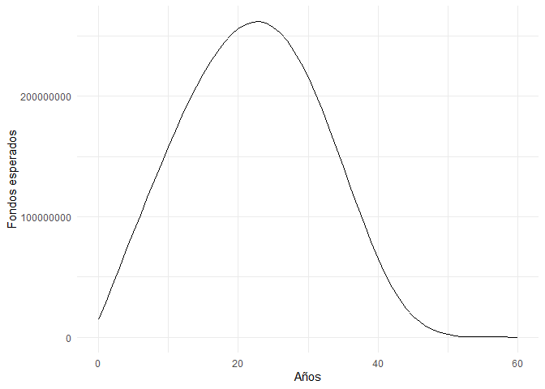

```r
ggplot(flows_2, aes(x = c(age - 50), y = E_funds_e_2)) +
  geom_line() +
  theme_minimal() +
  labs(y = "Fondos esperados", x = "Años")
```

Esto se debe a que conforme se va avanzando se va obteniendo el dinero de las primas, y con estas se van acumulando intereses. A pesar de que se tienen decesos no son tantos como para tener que cubrir todo lo que se ha acumulado en primas e intereses sobre estas, esto hasta llegar al punto más alto de la curva. Sin embargo, posterior a este punto se siguen acumulando primas e intereses, pero en este caso se tienen más decesos por lo que hay que pagar una mayor cantidad de los seguros y a su vez se tienen menor cantidad de primas y se acumulan menos intereses.

4. Considerando el primer escenario (parte a.) y una única vida, se debe generar un vector que muestra la pérdida esperada para la compañía de seguros en función del año en que ocurre la pérdida.

**Figura 2: Pérdida esperada según la edad de muertes**

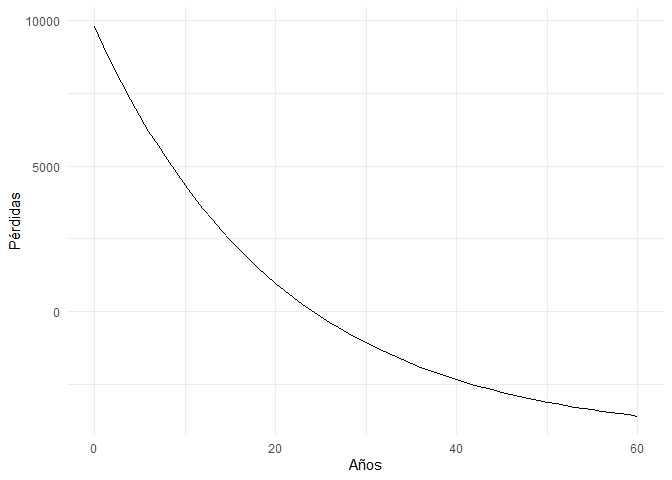

```r
v <- 1 / (1.05)
v_acum <- v^(0:60)
n <- length(v_acum)
L <- 10000 * v_acum - net_premium * cumsum(v_acum)

ggplot(, aes(x = 0:60, y = L)) +
  geom_line() +
  theme_minimal() +
  labs(y = "Pérdidas", x = "Años")
```

### Preguntas

1. ¿Cuál es la probabilidad de que la pérdida de la compañía sea mayor a 5.000? ¿A qué edad se podría asegurar que la compañía no presentará pérdidas mayores a 5.000 para esta póliza individual si a esa edad el individuo sigue con vida?

Con $P$ es la prima neta, $S$ es el beneficio. Para la primera pregunta se tiene que las perdidas se pueden modelar mediante la siguiente variable aleatoria.

$$L=Sv^{K_[x]+1}-P\frac{1-v^{K_{[x]+1}}}{d}$$

Entonces lo que se quiere se quiere es

$$\mathbb{P}\left(5000 \leq L \right) =
1-\mathbb{P}\left(K_{[x]}+1>\underbrace{\frac{\ln\left(\frac{S+\frac{P}{d}}{5000+\frac{P}{d}}\right)}{\ln(1+i)}}_{\tau}
\right)$$
Hay que tener presente que pueden obtener números no enteros, por lo que se debe tomar $\lfloor\tau\rfloor$, entonces lo anterior es $1-_ {\lfloor\tau\rfloor} p_{x}$. Entonces se puede programar la siguiente función, notanto que esto es la probabilidad de que el individuo sobreviva esa cantidad de tiempo

```r
probability_loss <- function(P, S, i, amount, x) {
  v <- 1 / (1 + i)
  d <- 1 - v
  numerator <- log((S + P / d) / (amount + P / d))
  denominator <- log(1 + i)
  t <- floor(numerator / denominator)
  r <- c(pxt(life_table, x = x, t = t), t)
  return(r)
}
```

Con esta función se puede calcular entonces que la probabilidad de tener pérdidas mayores a 5.000 es

```r
p_5000 <- probability_loss(net_premium, 10000, 0.05, 5000, 50)
```

Probabilidad de tener pérdidas mayores a 5.000 es 0,06268. Y la edad a la que se puede asegurar que se tienen pérdidas no mayores a 5.000 es 58

2. ¿Cuál es la probabilidad de qué la compañía no presente pérdida? ¿A qué edad se podría asegurar que la compañía no presentará pérdidas para esta póliza individual si a esa edad el individuo sigue con vida?

Este caso es análogo al anterior basta cambiar 5.000 por 0, y se desea la probabilidad de no tener pérdidas

```r
p_0 <- probability_loss(net_premium, 10000, 0.05, 0, 50)
```

Entonces las probabilidades de tener pérdidades menores a 0 es 0,63279 y la edad es 74.